# Chapter 7 - Ensemble methods

```r
mydata=read.csv("Data/dbm_final.csv")
mydata$region=as.factor(mydata$region)
mydata$yachat=as.factor(mydata$yachat)
mydata.train=mydata[mydata$train==1,-c(12,13,14)]
mydata.test=mydata[mydata$test==1,-c(12,13,14)]
```

The bagging method and random forests are illustrated here with the help of the function `randomForest` which is in the library of the same name, so you must have it installed beforehand. A large number of options are available with this function, many of which are options relating to the trees that will populate the forest and which we saw in the last chapter. The two options that will be of particular interest to us here are `ntree` (number of trees in the forest) and `mtry`, which represents the number of candidate predictors that are randomly chosen at each split of the tree. If `mtry` takes the value $p$, where $p$ is the total number of predictors in the model, then we are in the case of a simple tree bagging algorithm. If `mtry` is less than $p$ (by default $\sqrt{p}$ for classification trees and $p/3$ for regression trees), then the algorithm implemented is that of random forests.

Let’s first look at the results of a simple bagging (here, 10 predictors are available to predict a customer’s purchase). **Note that the response variable must be coded as a factor for a classification (not regression) forest to be performed.**

```r
library(randomForest)
set.seed(1234)
rf=randomForest(yachat~.,data=mydata.train,ntree=500,mtry=10)
rf
```

```
##
## Call:
##  randomForest(formula = yachat ~ ., data = mydata.train, ntree = 500,      mtry = 10)
##                Type of random forest: classification
##                      Number of trees: 500
## No. of variables tried at each split: 10
##
##         OOB estimate of  error rate: 16.2%
## Confusion matrix:
##     0  1 class.error
## 0 740 50  0.06329114
## 1 112 98  0.53333333
```

The reported out-of-bag (OOB) error rate is 16.2%. This means that 16.2% of the observations are misclassified. The confusion matrix gives the details of these errors (rows: true classes, columns: predicted classes). We can see that the false positive rate is 0.063 and that the false negative rate is 0.53, which is very high.

Let’s see now how we can use the obtained forest to predict the observations of the test data:

```r
predrf=predict(rf,newdata=mydata.test)
head(predrf)
```

```
## 1001 1002 1003 1004 1005 1006
##    0    0    0    0    0    0
## Levels: 0 1
```

The different error rates on the test data can be calculated as follows:

```r
# Error rate
sum(predrf!=mydata.test$yachat)/length(predrf)
```

```
## [1] 0.16512
```

```r
# Confusion matrix
M=table(predrf,mydata.test$yachat,dnn=c("Prediction","Observation"))
M
```

```
##           Observation
## Prediction     0     1
##          0 72121 11812
##          1  4700 11367
```

```r
# False positive rate
M[2,1]/(M[2,1]+M[1,1])
```

```
## [1] 0.06118119
```

```r
# False negative rate
M[1,2]/(M[2,2]+M[1,2])
```

```
## [1] 0.5095992
```

We could also construct the ROC curve and calculate the AUC of this model, as we saw for logistic regression. The code is identical to what we have seen in this chapter and we do not detail it here.

Let us now see if the results obtained differ when the random forest algorithm is used, instead of simple bagging - i.e. randomly selecting a number of candidate variables at each node. The code is identical, we just remove the `mtry=10` option to leave the default value.

```r
set.seed(1234)
rf2=randomForest(yachat~.,data=mydata.train,ntree=500)
rf2
```

```
##
## Call:
##  randomForest(formula = yachat ~ ., data = mydata.train, ntree = 500)
##                Type of random forest: classification
##                      Number of trees: 500
## No. of variables tried at each split: 3
##
##         OOB estimate of  error rate: 16.1%
## Confusion matrix:
##     0  1 class.error
## 0 753 37  0.04683544
## 1 124 86  0.59047619
```

```r
rf2=randomForest(yachat~.,data=mydata.train,ntree=500)
rf2
```

```
##
## Call:
##  randomForest(formula = yachat ~ ., data = mydata.train, ntree = 500)
##                Type of random forest: classification
##                      Number of trees: 500
## No. of variables tried at each split: 3
##
##         OOB estimate of  error rate: 16.1%
## Confusion matrix:
##     0  1 class.error
## 0 758 32  0.04050633
## 1 129 81  0.61428571
```

```r
predrf=predict(rf,newdata=mydata.test)

# Error rate
sum(predrf!=mydata.test$yachat)/length(predrf)
```

```
## [1] 0.16511
```

```r
# Confusion matrix
M=table(predrf,mydata.test$yachat,dnn=c("Prediction","Observation"))
M
```

```
##           Observation
## Prediction     0     1
##          0 72121 11811
##          1  4700 11368
```

```r
# False positive rate
M[2,1]/(M[2,1]+M[1,1])
```

```
## [1] 0.06118119
```

```r
# False negative rate
M[1,2]/(M[2,2]+M[1,2])
```

```
## [1] 0.5095561
```

We can also quickly look at the effect of the number of trees on the OOB error, as in the code below:

```r
set.seed(123)
n.arbre=seq(1,1000,by=50)
erreur=NULL
for (i in n.arbre)
{
  rf=randomForest(yachat~.,data=mydata.train,ntree=i)
  erreur=c(erreur,sum(rf$err.rate[,1])/rf$ntree)
}
erreur
```

```
##  [1] 0.2383562 0.1820645 0.1874252 0.1739005 0.1747530 0.1731726 0.1695323
##  [8] 0.1706349 0.1720765 0.1687203 0.1644537 0.1662673 0.1686861 0.1676535
## [15] 0.1641314 0.1645181 0.1641989 0.1665423 0.1691863 0.1653500
```

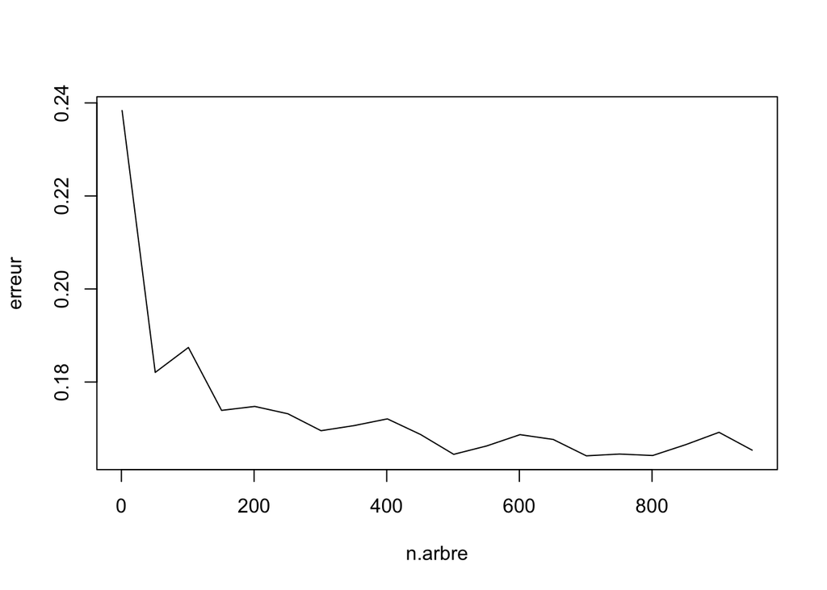

```r
plot(n.arbre, erreur,type="l")
```

We can see that the error decreases with the number of trees, but that from a certain number of trees, the computational cost is perhaps greater than the gain in error.

It is finally possible to obtain, as for the trees, importance measures for each variable using the `importance` function. We don’t detail the calculation of these measures here because this will be covered in the advanced data mining course, but the code is given here. Note that there is an option in the `randomForest` function that allows you to calculate or not the variable importance measures, and it takes the value `FALSE` by default. So in order to get these measures, we need to rerun the random forest algorithm with the value `TRUE`. The code is as follows:

```r
set.seed(12355)
rf3=randomForest(yachat~.,data=mydata.train,ntree=500,importance=TRUE)
importance(rf3,type=1)
```

```
##                MeanDecreaseAccuracy
## sexe                      20.202211
## age                       35.730115
## revenu                     8.211181
## region                     0.616944
## conjoint                  10.531387
## anneeclient                3.435862
## semainedernier            13.153384
## montantdernier            37.196149
## montantunan                6.739665
## achatunan                 20.624066
```

Of course, we can also use all the functions seen above with regression trees and not classification trees. The code is the same, and here is an example where we want to predict the amount spent in the variable `ymontant`:

```r
mydata=read.csv("Data/dbm_final.csv")
mydata$region=as.factor(mydata$region)
mydata.train=mydata[mydata$train==1 & mydata$yachat==1,-c(11,13,14)]
mydata.test=mydata[mydata$test==1& mydata$yachat==1,-c(11,13,14)]

# Random forest
set.seed(3344)
rf4=randomForest(ymontant~.,data=mydata.train,ntree=500)
rf4
```

[output not shown]

```r
1-30.21281/var(mydata.train$ymontant)
```

```
## [1] 0.8275998
```

We see that the error rate is now calculated as a function of the MSE. The calculated $R^2$ is more interpretable than the MSE, and is simply calculated as follows:
$$R^2=1-\frac{MSE}{Var(Y)}$$
Here is the code to calculate this rate on the test data:

```r
predrf=predict(rf4,newdata=mydata.test)
# MSE
MSE=mean((predrf-mydata.test$ymontant)^2)
MSE
```

```
## [1] 31.44919
```

```r
# R2
R2=1-MSE/var(mydata.test$ymontant)
R2
```

```
## [1] 0.8263388
```

## Boosting on trees

We will now see how to run the adaboost algorithm seen in the lecture notes. To do this, we will use the `adabag` library of R. The adaboost algorithm seen in the lecture notes is developed for the classification case, and so we return to that example here.

```r
mydata=read.csv("Data/dbm_final.csv")
mydata$region=as.factor(mydata$region)
mydata$yachat=as.factor(mydata$yachat)
mydata.train=mydata[mydata$train==1,-c(12,13,14)]
mydata.test=mydata[mydata$test==1,-c(12,13,14)]
```

The `boosting` function of the `adabag` library allows to implement the adaboost algorithm for classification trees. The underlying function is the `rpart` function that we saw in the previous course. The code is as follows for a boosting using 100 trees and a maximum depth of 10 for each tree:

```r
library(adabag)
# boosting with trees of depth 10
myboost=boosting(yachat~., data=mydata.train, mfinal = 100,
    coeflearn = 'Freund', control=rpart.control(maxdepth=10))
myboost$importance
```

```
##      achatunan            age    anneeclient       conjoint montantdernier
##       7.554597      14.386876      19.026496       1.523716      10.847144
##    montantunan         region         revenu semainedernier           sexe
##      17.408698       8.872902       3.149261      14.329235       2.901074
```

```r
pred=predict(myboost, newdata=mydata.test)
pred$error
```

```
## [1] 0.17865
```

```r
M=pred$confusion

# False positive rate
M[2,1]/(M[2,1]+M[1,1])
```

```
## [1] 0.08245141
```

```r
# False negative rate
M[1,2]/(M[2,2]+M[1,2])
```

```
## [1] 0.4974762
```